# Analise temporal

Sheila Andrade

18 de novembro de 2019

# Exercício Análise Temporal

# Parte 1 - ajuste por regressão linear

Carregamento dos pacotes utilizados durante a realização dos exercícios.

```r
library(readxl)
library(tidyverse)
```

```r
library(cowplot)
library(knitr)
library(minpack.lm)
library(plyr)
library(epiR)
library(BiasedUrn)
library (nlme)
library (agricolae)
```

Com base nos dados disponibilizados para cada grupo, que consistem em avaliações de intensidade de doença o tempo, execute os seguintes passos para analisar os dados: carregamento dos dados:

```r
dat1<- read_excel("Dados (2).xlsx")
dat1
```

```
## # A tibble: 72 x 4
##    cultivar     r     t     y
##    <chr>    <dbl> <dbl> <dbl>
##  1 Magaly       1     0  0.95
##  2 Magaly       2     0  0.86
##  3 Magaly       3     0  0.91
##  4 Magaly       1     7  2.92
##  5 Magaly       2     7  5.67
##  6 Magaly       3     7  4.3
##  7 Magaly       1    14  6.4
##  8 Magaly       2    14  5.67
##  9 Magaly       3    14  4.7
## 10 Magaly       1    21  7.16
## # ... with 62 more rows
```

# Questão 1

Considerando o valor médio de severidade (y) nas repetições, represente graficamente o progresso da doença de duas diferentes formas: a severidade média da doença no tempo e a taxa absoluta no tempo. Faça um gráfico de dispersão de pontos conectados por linhas.

Cálculo do valor médio da severidade x tempo

```r
dat2<-dat1 %>%
  group_by(cultivar,t) %>%
  dplyr:: summarise(s=mean(y))
dat2
```

```
## # A tibble: 24 x 3
## # Groups:   cultivar [3]
##    cultivar     t      s
##    <chr>    <dbl>  <dbl>
##  1 Amanda       0  3.82
##  2 Amanda       7 13.6
##  3 Amanda      14 21.4
##  4 Amanda      21 40.9
##  5 Amanda      28 70.3
##  6 Amanda      42 81.2
##  7 Amanda      63 93.2
##  8 Amanda     112 94.7
##  9 Magaly       0  0.907
## 10 Magaly       7  4.30
## # ... with 14 more rows
```

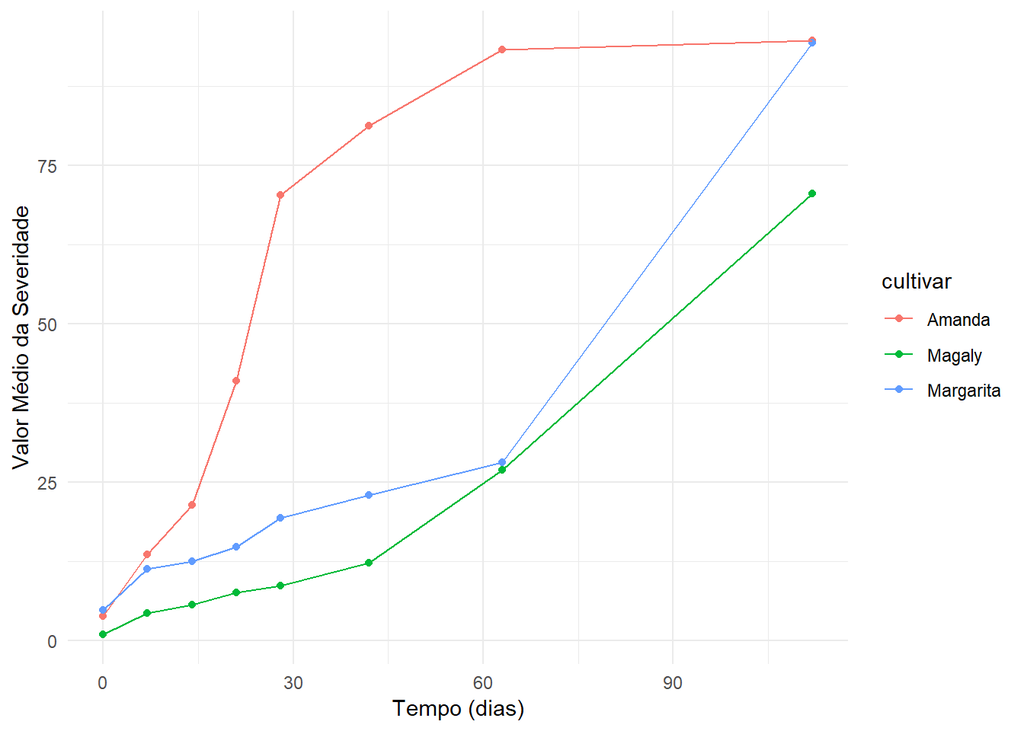

```r
  dat2 %>%
  ggplot(aes(t,s, color=cultivar)) + geom_point() +
  geom_line()+ labs(x = "Tempo (dias)", y = "Valor Médio da Severidade")+theme_minimal()
```

```r
 dat2
```

```
## # A tibble: 24 x 3
## # Groups:   cultivar [3]
##    cultivar     t      s
##    <chr>    <dbl>  <dbl>
##  1 Amanda       0  3.82
##  2 Amanda       7 13.6
##  3 Amanda      14 21.4
##  4 Amanda      21 40.9
##  5 Amanda      28 70.3
##  6 Amanda      42 81.2
##  7 Amanda      63 93.2
##  8 Amanda     112 94.7
##  9 Magaly       0  0.907
## 10 Magaly       7  4.30
## # ... with 14 more rows
```

Cálculo da taxa abosoluta (dy/dt) x tempo

```r
t = c(0, 7, 14, 21, 28, 42, 63, 112)
incMg= c (0.90, 4.29, 5.59, 7.59, 8.66, 12.23, 26.87, 70.56)
incA= c (3.81, 13.62, 21.43, 40.92, 70.31, 81.20, 93.23, 94.66)
incMA= c (4.78, 11.25, 12.43, 14.78, 19.35, 22.96, 28.08, 94.30)

y1=incMg/100
y2=incA/100
y3=incMA/100
curva1 <- data.frame(t, y1)
curva2 <- data.frame(t, y2)
curva3 <- data.frame(t, y3)

dydt1= c(0,
curva1[2,2]-curva1[1,2],
curva1[3,2]-curva1[2,2],
curva1[4,2]-curva1[3,2],
curva1[5,2]-curva1[4,2],
curva1[6,2]-curva1[5,2],
curva1[7,2]-curva1[6,2],
curva1[8,2]-curva1[7,2])
dydt1
```

```
## [1] 0.0000 0.0339 0.0130 0.0200 0.0107 0.0357 0.1464 0.4369
```

```r
dydt2=c(0,
curva2[2,2]-curva2[1,2],
curva2[3,2]-curva2[2,2],
curva2[4,2]-curva2[3,2],
curva2[5,2]-curva2[4,2],
curva2[6,2]-curva2[5,2],
curva2[7,2]-curva2[6,2],
curva2[8,2]-curva2[7,2])
dydt2
```

```
## [1] 0.0000 0.0981 0.0781 0.1949 0.2939 0.1089 0.1203 0.0143
```

```r
dydt3=c(0,
curva3[2,2]-curva3[1,2],
curva3[3,2]-curva3[2,2],
curva3[4,2]-curva3[3,2],
curva3[5,2]-curva3[4,2],
curva3[6,2]-curva3[5,2],
curva3[7,2]-curva3[6,2],
curva3[8,2]-curva3[7,2])
dydt3
```

```
## [1] 0.0000 0.0647 0.0118 0.0235 0.0457 0.0361 0.0512 0.6622
```

```r
t2=c(0,
(curva1[2,1]+curva1[1,1])/2,
(curva1[3,1]+curva1[2,1])/2,
(curva1[4,1]+curva1[3,1])/2,
(curva1[5,1]+curva1[4,1])/2,
(curva1[6,1]+curva1[5,1])/2,
(curva1[7,1]+curva1[6,1])/2,
(curva1[8,1]+curva1[7,1])/2)
t2
```

```
## [1]  0.0  3.5 10.5 17.5 24.5 35.0 52.5 87.5
```

```r
y1=c(0,
(curva1[2,2]+curva1[1,2])/2,
(curva1[3,2]+curva1[2,2])/2,
(curva1[4,2]+curva1[3,2])/2,
(curva1[5,2]+curva1[4,2])/2,
(curva1[6,2]+curva1[5,2])/2,
(curva1[7,2]+curva1[6,2])/2,
(curva1[8,2]+curva1[7,2])/2)
y1
```

```
## [1] 0.00000 0.02595 0.04940 0.06590 0.08125 0.10445 0.19550 0.48715
```

```r
y2=c(0,
(curva2[2,2]+curva2[1,2])/2,
(curva2[3,2]+curva2[2,2])/2,
(curva2[4,2]+curva2[3,2])/2,
(curva2[5,2]+curva2[4,2])/2,
(curva2[6,2]+curva2[5,2])/2,
(curva2[7,2]+curva2[6,2])/2,
(curva2[8,2]+curva2[7,2])/2)
y2
```

```
## [1] 0.00000 0.08715 0.17525 0.31175 0.55615 0.75755 0.87215 0.93945
```

```r
y3=c(0,
(curva3[2,2]+curva3[1,2])/2,
(curva3[3,2]+curva3[2,2])/2,
(curva3[4,2]+curva3[3,2])/2,
(curva3[5,2]+curva3[4,2])/2,
(curva3[6,2]+curva3[5,2])/2,
(curva3[7,2]+curva3[6,2])/2,
(curva3[8,2]+curva3[7,2])/2)
y3
```

```
## [1] 0.00000 0.08015 0.11840 0.13605 0.17065 0.21155 0.25520 0.61190
```

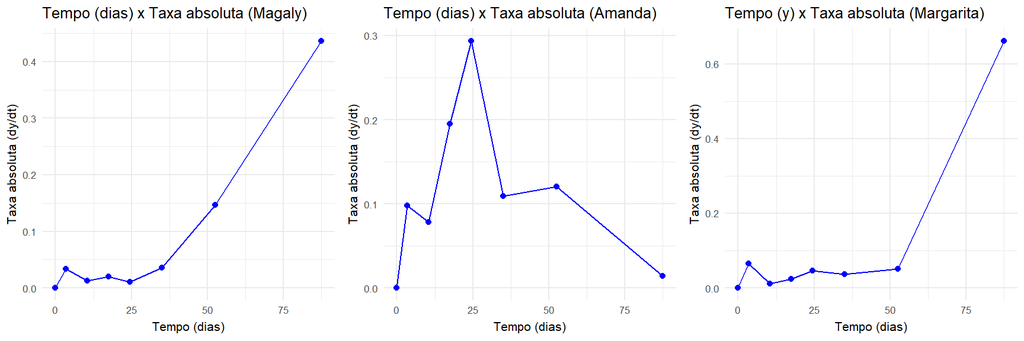

```r
#Tempo e taxa absoluta Magaly
dydtMag <- data.frame(dydt1, t2)
Magaly<-ggplot(dydtMag, aes(t2, dydt1))+
                geom_point(color="blue")+
                geom_line(stat = "identity",color="blue")+
                ggtitle("Tempo (dias) x Taxa absoluta (Magaly)")+
                labs(x = "Tempo (dias)", y = "Taxa absoluta (dy/dt)")+
                theme_minimal(base_size = 8)


#Tempo e taxa absoluta Amanda
dydtAman<- data.frame(dydt2, t2)
Amanda<-ggplot(dydtAman, aes(t2, dydt2))+
                geom_point()+
                geom_point(color="blue")+
                geom_line(stat = "identity",color="blue")+
                ggtitle("Tempo (dias) x Taxa absoluta (Amanda)")+
                labs(x = "Tempo (dias)", y = "Taxa absoluta (dy/dt)")+
                theme_minimal(base_size = 8)

#Tempo e taxa absoluta Margarita
dydtMa<- data.frame(dydt3, t2)
Margarita<-ggplot(dydtMa, aes(t2, dydt3))+
                geom_point()+
                geom_point(color="blue")+
                geom_line(stat = "identity",color="blue")+
                ggtitle("Tempo (y) x Taxa absoluta (Margarita)")+
                labs(x = "Tempo (dias)", y = "Taxa absoluta (dy/dt)")+
                theme_minimal(base_size = 8)



cowplot::plot_grid(Magaly, Amanda, Margarita, ncol = 3)
```

# Questão 2

Ainda para os valores médios de y, calcule e apresente os valores de y e os valores de y linearizados para 4 modelos ( y*E, y*M, y*L e y*G), para cada tempo t em cada uma das três epidemias. Em seguida, apresente os gráficos de cada um dos 4 valores de y*, para cada modelo, no tempo (ex. y*M versus t, etc.).

### MAGALY

```r
#Cálculo para Magaly
curva1<-mutate(curva1, yexp = log(y1))             #exponito
curva1<-mutate(curva1,ymon = log(1/(1-y1)))        #monito
curva1<-mutate(curva1,ylog = log(y1/(1-y1)))       #logito
curva1<-mutate(curva1,ygom = -log(-log(y1)))      #gompito

## Tabela Magaly
kable( curva1 ,format="pandoc", caption = "Diferentes modelos Magaly"
       , align = c('l', 'c', 'r', 'r', 'c', 'l')
       , col.names = c("t","y","yexp","ymon","ylog","ygom")
       , row.names = TRUE
       , digits = 3
       , format.args = list( decimal.mark = ","))
```

Diferentes modelos Magaly

|  | t | y | yexp | ymon | ylog | ygom |
| --- | --- | --- | --- | --- | --- | --- |
| 1 | 0 | 0,009 | -4,711 | 0,009 | -4,701 | -1,550 |
| 2 | 7 | 0,043 | -3,149 | 0,044 | -3,105 | -1,147 |
| 3 | 14 | 0,056 | -2,884 | 0,058 | -2,827 | -1,059 |
| 4 | 21 | 0,076 | -2,578 | 0,079 | -2,499 | -0,947 |
| 5 | 28 | 0,087 | -2,446 | 0,091 | -2,356 | -0,895 |
| 6 | 42 | 0,122 | -2,101 | 0,130 | -1,971 | -0,743 |
| 7 | 63 | 0,269 | -1,314 | 0,313 | -1,001 | -0,273 |
| 8 | 112 | 0,706 | -0,349 | 1,223 | 0,874 | 1,054 |

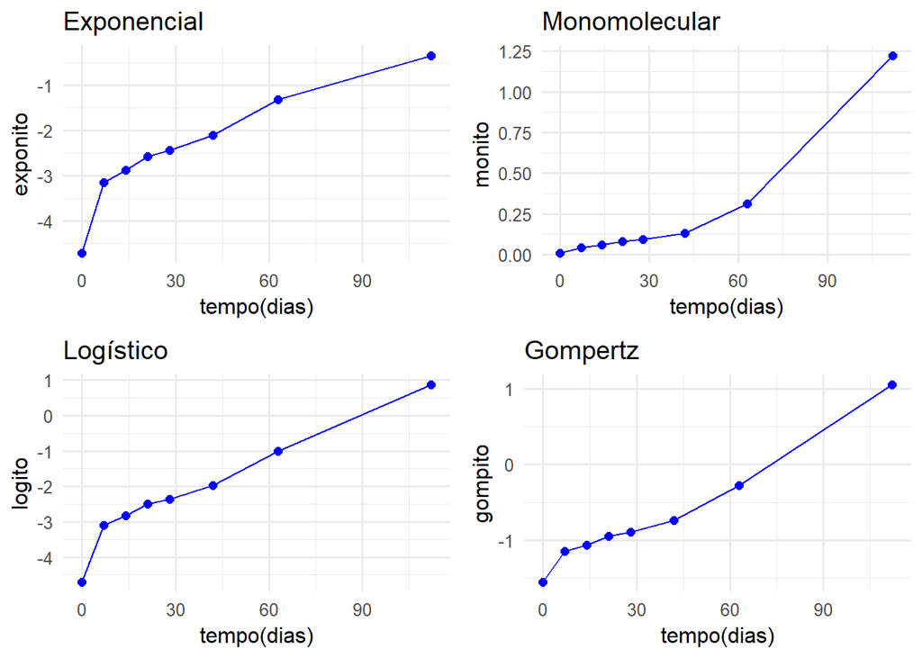

```r
#Gráfico Magaly y* para cada modelo x tempo

M1<-ggplot(curva1, aes(t, yexp))+
  geom_point(position = position_dodge(width = 0.90),size=2,color="blue")+
  geom_line(stat ="identity",color="blue")+ggtitle("Exponencial")+xlab("tempo(dias)")+ylab("exponito")+
   theme_minimal(base_size = 12)

M2<-ggplot(curva1, aes(t, ymon))+
  geom_point(position = position_dodge(width = 0.90),size=2,color="blue")+
  geom_line(stat ="identity",color="blue")+ggtitle("Monomolecular")+xlab("tempo(dias)")+ylab("monito")+
   theme_minimal(base_size = 12)

M3<-ggplot(curva1, aes(t, ylog))+
  geom_point(position = position_dodge(width = 0.90),size=2,color="blue")+
  geom_line(stat ="identity",color="blue")+ggtitle("Logístico")+xlab("tempo(dias)")+ylab("logito")+
   theme_minimal(base_size = 12)

M4<-ggplot(curva1, aes(t, ygom))+
  geom_point(position = position_dodge(width = 0.90),size=2,color="blue")+
  geom_line(stat ="identity",color="blue")+ggtitle("Gompertz")+xlab("tempo(dias)")+ylab("gompito")+
   theme_minimal(base_size = 12)

plot_grid(M1,M2,M3,M4)
```

### Amanda

```r
#Cálculo para Amanda
curva2<-mutate(curva2, yexp = log(y2))               #exponito
curva2<-mutate(curva2,ymon = log(1/(1-y2)))          #monito
curva2<-mutate(curva2,ylog = log(y2/(1-y2)))          # logito
curva2<-mutate(curva2,ygom = -log(-log(y2)))         # gompito
# Tabela Amanda
kable( curva2 ,format="pandoc", caption = "Diferentes modelos Amanda"
       , align = c('l', 'c', 'r', 'r', 'c', 'l')
       , col.names = c("t","y","yexp","ymon","ylog","ygom")
       , row.names = TRUE
       , digits = 3
       , format.args = list( decimal.mark = ","))
```

Diferentes modelos Amanda

|  | t | y | yexp | ymon | ylog | ygom |
| --- | --- | --- | --- | --- | --- | --- |
| 1 | 0 | 0,038 | -3,268 | 0,039 | -3,229 | -1,184 |
| 2 | 7 | 0,136 | -1,994 | 0,146 | -1,847 | -0,690 |
| 3 | 14 | 0,214 | -1,540 | 0,241 | -1,299 | -0,432 |
| 4 | 21 | 0,409 | -0,894 | 0,526 | -0,367 | 0,113 |
| 5 | 28 | 0,703 | -0,352 | 1,214 | 0,862 | 1,043 |
| 6 | 42 | 0,812 | -0,208 | 1,671 | 1,463 | 1,569 |
| 7 | 63 | 0,932 | -0,070 | 2,693 | 2,623 | 2,658 |
| 8 | 112 | 0,947 | -0,055 | 2,930 | 2,875 | 2,903 |

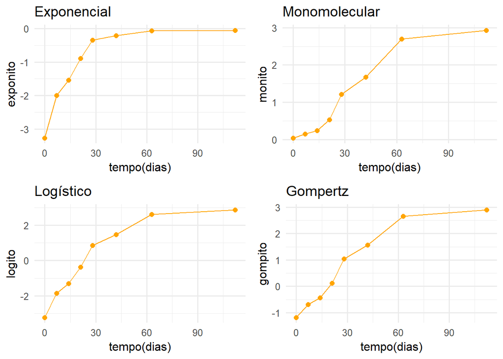

```r
#  Gráfico Amanda y* para cada modelo x tempo
A1<-ggplot(curva2, aes(t, yexp))+
  geom_point(position = position_dodge(width = 0.90),size=2,color="orange")+
  geom_line(stat ="identity",color="orange")+ggtitle("Exponencial")+xlab("tempo(dias)")+ylab("exponito")+
   theme_minimal(base_size = 12)

A2<-ggplot(curva2, aes(t, ymon))+
  geom_point(position = position_dodge(width = 0.90),size=2,color="orange")+
  geom_line(stat ="identity",color="orange")+ggtitle("Monomolecular")+xlab("tempo(dias)")+ylab("monito")+
   theme_minimal(base_size = 12)

A3<-ggplot(curva2, aes(t, ylog))+
  geom_point(position = position_dodge(width = 0.90),size=2,color="orange")+
  geom_line(stat ="identity",color="orange")+ggtitle("Logístico")+xlab("tempo(dias)")+ylab("logito")+
   theme_minimal(base_size = 12)

A4<-ggplot(curva2, aes(t, ygom))+
  geom_point(position = position_dodge(width = 0.90),size=2,color="orange")+
  geom_line(stat ="identity",color="orange")+ggtitle("Gompertz")+xlab("tempo(dias)")+ylab("gompito")+
   theme_minimal(base_size = 12)

plot_grid(A1,A2,A3,A4)
```

### Margarita

```r
# Cálulo Margarita
curva3<-mutate(curva3,yexp = log(y3))               #exponito
curva3<-mutate(curva3,ymon = log(1/(1-y3)))         #monito
curva3<-mutate(curva3,ylog = log(y3/(1-y3)))        #logito
curva3<-mutate(curva3,ygom = -log(-log(y3)))        #gompito


#Tabela Margarita
kable(curva3 ,format="pandoc", caption = "Diferentes modelos Margarita"
       , align = c('l', 'c', 'r', 'r', 'c', 'l')
       , col.names = c("t","y","yexp","ymon","ylog","ygom")
       , row.names = TRUE
       , digits = 3
       , format.args = list( decimal.mark = ","))
```

Diferentes modelos Margarita

|  | t | y | yexp | ymon | ylog | ygom |
| --- | --- | --- | --- | --- | --- | --- |
| 1 | 0 | 0,048 | -3,041 | 0,049 | -2,992 | -1,112 |
| 2 | 7 | 0,112 | -2,185 | 0,119 | -2,065 | -0,782 |
| 3 | 14 | 0,124 | -2,085 | 0,133 | -1,952 | -0,735 |
| 4 | 21 | 0,148 | -1,912 | 0,160 | -1,752 | -0,648 |
| 5 | 28 | 0,194 | -1,642 | 0,215 | -1,427 | -0,496 |
| 6 | 42 | 0,230 | -1,471 | 0,261 | -1,211 | -0,386 |
| 7 | 63 | 0,281 | -1,270 | 0,330 | -0,940 | -0,239 |
| 8 | 112 | 0,943 | -0,059 | 2,865 | 2,806 | 2,836 |

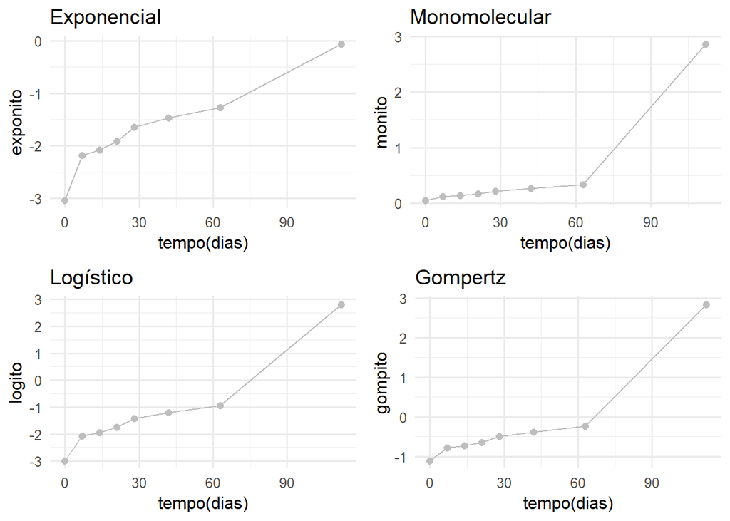

```r
#  Gráfico Margarita y* para cada modelo x tempo
MA1<-ggplot(curva3, aes(t, yexp))+
  geom_point(position = position_dodge(width = 0.90),size=2,color="gray")+
  geom_line(stat ="identity",color="gray")+ggtitle("Exponencial")+xlab("tempo(dias)")+ylab("exponito")+
   theme_minimal(base_size = 12)

MA2<-ggplot(curva3, aes(t, ymon))+
  geom_point(position = position_dodge(width = 0.90),size=2,color="gray")+
  geom_line(stat ="identity",color="gray")+ggtitle("Monomolecular")+xlab("tempo(dias)")+ylab("monito")+
   theme_minimal(base_size = 12)

MA3<-ggplot(curva3, aes(t, ylog))+
  geom_point(position = position_dodge(width = 0.90),size=2,color="gray")+
  geom_line(stat ="identity",color="gray")+ggtitle("Logístico")+xlab("tempo(dias)")+ylab("logito")+
   theme_minimal(base_size = 12)

MA4<-ggplot(curva3, aes(t, ygom))+
  geom_point(position = position_dodge(width = 0.90),size=2,color="gray")+
  geom_line(stat ="identity",color="gray")+ggtitle("Gompertz")+xlab("tempo(dias)")+ylab("gompito")+
   theme_minimal(base_size = 12)

plot_grid(MA1,MA2,MA3,MA4)
```

Junção dos gráficos de cada modelo para cada cultivar, diferenciados por cor.

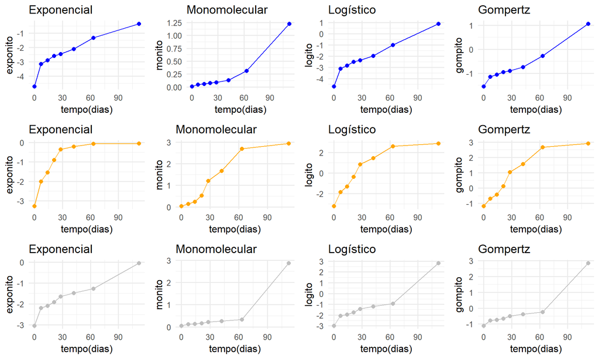

```r
plot_grid(M1,M2,M3,M4,A1,A2,A3,A4,MA1,MA2,MA3,MA4)
```

# Questão 3

Com base na análise gráfica (questões 1 e 2) discuta qual(ais) modelo(s) possivelmente se ajusta(m) aos dados observados de progresso da doença e os motivos para a decisão.

Observando a curva de progresso da doença para cada para Magaly e Margarita o melhor modelo é o exponencial. Já para Amanda o melhor modelo é o Monomolecular. Quando se observa os dados linearizados os modelos que melhor se ajustaram aos dados foram o logístico e o gompertz. Assim, os modelos que explicam melhor a epidemia são o Logístico e o gompertz pois com os dados linearizados obtem-se uma taxa de progresso padronizada ao longo da curva o que nos permite a comparação.

# Questão 4

Escolha dois modelos que parecem se ajustar visualmente aos dados de progresso e efetue uma regressão linear para verificar estatisticamente o melhor ajuste. Continue usando os valores médios dos tratamentos.

```r
# Regressão linear para Magaly
rg1<-  select(curva1,t,y1,yexp,ymon,ylog,ygom)

# Aplica a regressão linear para o logito
lm1<-lm(ylog ~ t, data = rg1)
lm1
```

```
##
## Call:
## lm(formula = ylog ~ t, data = rg1)
##
## Coefficients:
## (Intercept)            t
##    -3.72883      0.04266
```

```r
# Apresenta os dois coeficientes do modelo linear
c_lm1<-coef(lm1)
c_lm1
```

```
## (Intercept)           t
## -3.72882831  0.04266275
```

```r
# Intervalo de confiança dos parâmetros
c_A <- confint(lm1)
c_A
```

```
##                   2.5 %      97.5 %
## (Intercept) -4.31565035 -3.14200628
## t            0.03085136  0.05447413
```

```r
# Aplica função inversa para o intercepto para obter o y0
conf_A <- 1/(1+exp(-c_lm1[1])) # apenas para o intercepto
conf_A #y0 destransformado
```

```
## (Intercept)
##  0.02345749
```

```r
# Regressão linear para  Amanda, LOGITO
rg2<-  select(curva2,t,y2,yexp,ymon,ylog,ygom)

# Aplica a regressão linear
lm2<-lm(ylog ~ t, data = rg2)
lm2
```

```
##
## Call:
## lm(formula = ylog ~ t, data = rg2)
##
## Coefficients:
## (Intercept)            t
##     -1.7448       0.0524
```

```r
# Coeficientes do modelo linear
c_lm2<-coef(lm2)
c_lm2
```

```
## (Intercept)           t
## -1.74479432  0.05239988
```

```r
# Intervalo de confiança dos parâmetros
c_B <- confint(lm2)
c_B
```

```
##                   2.5 %      97.5 %
## (Intercept) -3.15141171 -0.33817694
## t            0.02408789  0.08071187
```

```r
# y0 destransformado
conf_B <- 1/(1+exp(-c_lm2[1]))
conf_B
```

```
## (Intercept)
##    0.148705
```

```r
# Regressão linear para a Cultivar Margarita, LOGITO
rg3<-  select(curva3,t,y3,yexp,ymon,ylog,ygom)

# Aplica a regressão linear
lm3<-lm(ylog ~ t, data = rg3)
lm3
```

```
##
## Call:
## lm(formula = ylog ~ t, data = rg3)
##
## Coefficients:
## (Intercept)            t
##    -2.81512      0.04525
```

```r
# Coeficientes do modelo linear
c_lm3<-coef(lm3)
c_lm3
```

```
## (Intercept)           t
## -2.81511910  0.04525081
```

```r
# Intervalo de confiança dos parâmetros
c_C <- confint(lm3)
c_C
```

```
##                  2.5 %      97.5 %
## (Intercept) -3.4698736 -2.16036460
## t            0.0320721  0.05842952
```

```r
# y0 destransformado
conf_C <- 1/(1+exp(-c_lm3[1]))
conf_C
```

```
## (Intercept)
##  0.05651262
```

```r
# Regressão linear para Magaly, GOMPITO
rg4<-  select(curva1,t,y1,yexp,ymon,ylog,ygom)

# Aplica a regressão linear
lm4<-lm(ygom ~ t, data = rg4)
lm4
```

```
##
## Call:
## lm(formula = ygom ~ t, data = rg4)
##
## Coefficients:
## (Intercept)            t
##     -1.4590       0.0213
```

```r
# Coeficientes do modelo linear
c_lm4<-coef(lm4)
c_lm4
```

```
## (Intercept)           t
## -1.45900718  0.02129603
```

```r
# Intervalo de confiança dos parâmetros
c_D <- confint(lm4)
c_D
```

```
##                  2.5 %      97.5 %
## (Intercept) -1.6376778 -1.28033655
## t            0.0176998  0.02489226
```

```r
# y0 Destransformado
conf_D <-exp(-exp(-c_lm4[1]))
conf_D
```

```
## (Intercept)
##  0.01354569
```

```r
# Regressão linear para Amanda, GOMPITO
rg5<-  select(curva2,t,y2,yexp,ymon,ylog,ygom)

# Aplica a regressão linear
lm5<-lm(ygom ~ t, data = rg5)
lm5
```

```
##
## Call:
## lm(formula = ygom ~ t, data = rg5)
##
## Coefficients:
## (Intercept)            t
##    -0.63668      0.03858
```

```r
# Coeficientes do modelo linear
c_lm5<-coef(lm5)
c_lm5
```

```
## (Intercept)           t
## -0.63667814  0.03858117
```

```r
# Intervalo de confiança dos parâmetros
c_E <- confint(lm5)
c_E
```

```
##                   2.5 %     97.5 %
## (Intercept) -1.45672620 0.18336992
## t            0.02207548 0.05508686
```

```r
# y0 destransformado
conf_E <-exp(-exp(-c_lm5[1]))
conf_E
```

```
## (Intercept)
##   0.1510429
```

```r
# Regressão linear para Margarita, GOMPITO
rg6<-  select(curva3,t,y3,yexp,ymon,ylog,ygom)

# Aplica a regressão linear
lm6<-lm(ygom ~ t, data = rg6)
lm6
```

```
##
## Call:
## lm(formula = ygom ~ t, data = rg6)
##
## Coefficients:
## (Intercept)            t
##    -1.33063      0.03165
```

```r
# Coeficientes do modelo linear
c_lm6<-coef(lm6)
c_lm6
```

```
## (Intercept)           t
## -1.33063263  0.03164639
```

```r
# Intervalo de confiança dos parâmetros
c_F <- confint(lm6)
c_F
```

```
##                  2.5 %      97.5 %
## (Intercept) -1.9620995 -0.69916578
## t            0.0189364  0.04435637
```

```r
#  y0 destransformado
conf_F <-exp(-exp(-c_lm6[1]))
conf_F
```

```
## (Intercept)
##   0.0227444
```

## Magaly

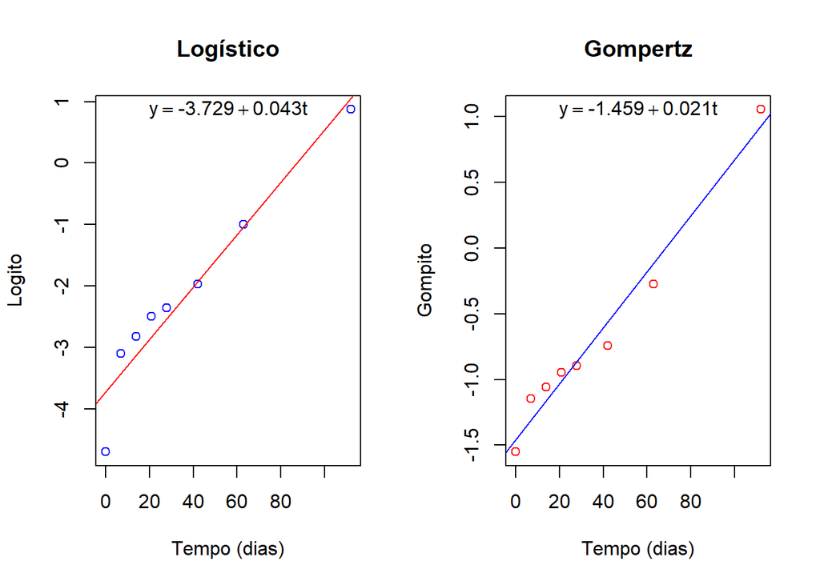

```r
# Gráficos da regresão linear para cada modelo
par(mfrow=c(1,2))

# Gráfico Logistico
plot (ylog ~ t, data = rg1, main="Logístico", type = c("p"),
      ylab = "Logito", xlab = "Tempo (dias)",col="blue")
abline ((coef(lm1)),col="red")
lm_coef_A <- round(coef(lm1), 3)
mtext(bquote(y == .(lm_coef_A[1]) + .(lm_coef_A[2])*t), adj=0.5, padj=1.5)


# Gráfico Gompertz
plot ( ygom ~ t, data = rg4, main="Gompertz", type=c("p"),
       ylab="Gompito", xlab="Tempo (dias)",col="red")
abline ((coef(lm4)),col="blue")
lm_coef_A <- round(coef(lm4), 3)
mtext(bquote(y == .(lm_coef_A[1]) + .(lm_coef_A[2])*t), adj=0.5, padj=1.5)
```

## Amanda

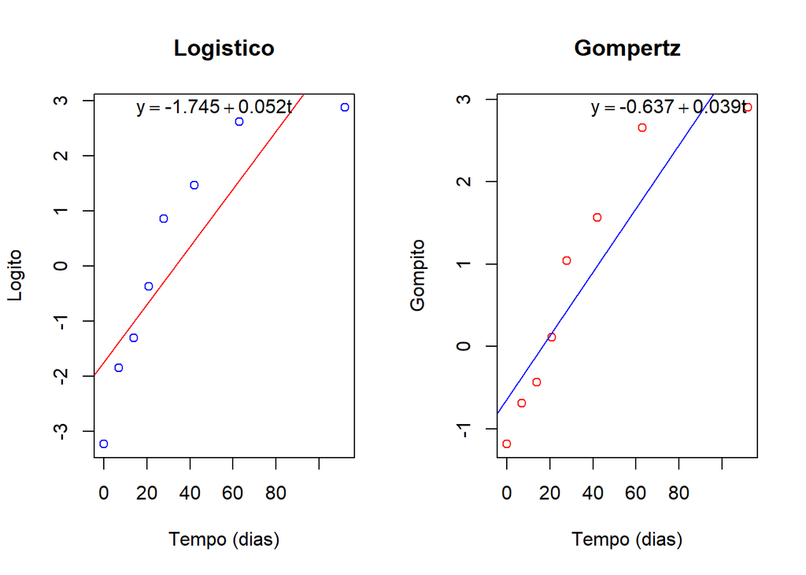

```r
# Gráficos da regresão linear para cada modelo
par(mfrow=c(1,2))

# Grafico Logistico
plot (ylog ~ t, data = rg2, main="Logistico", type = c("p"),
      ylab = "Logito", xlab = "Tempo (dias)",col="blue")
abline ((coef(lm2)),col="red")
lm_coef_B <- round(coef(lm2), 3)
mtext(bquote(y == .(lm_coef_B[1]) + .(lm_coef_B[2])*t), adj=0.4, padj=1.5)

# Grafico Gompertz
plot ( ygom ~ t, data = rg5, main="Gompertz", type=c("p"),
       ylab="Gompito", xlab="Tempo (dias)",col="red")
abline ((coef(lm5)),col="blue")
lm_coef_B <- round(coef(lm5), 3)
mtext(bquote(y == .(lm_coef_B[1]) + .(lm_coef_B[2])*t), adj=0.90, padj=1.5)
```

## Margarita

[figure not shown]

```r
# Gráficos da regresão linear para cada modelo
par(mfrow=c(1,2))

# Grafico Logistico
plot (ylog ~ t, data = rg3, main="Logistico", type = c("p"),
      ylab = "Logito", xlab = "Tempo (dias)",col="blue")
abline ((coef(lm3)),col="red")
lm_coef_C <- round(coef(lm3), 3)
mtext(bquote(y == .(lm_coef_C[1]) + .(lm_coef_C[2])*t), adj=0.1, padj=1.5)

# Grafico Gompertz
plot ( ygom ~ t, data = rg6, main="Gompertz", type=c("p"),
       ylab="Gompito", xlab="Tempo (dias)",col="red")
abline ((coef(lm6)),col="blue")
lm_coef_C <- round(coef(lm6), 3)
mtext(bquote(y == .(lm_coef_A[1]) + .(lm_coef_A[2])*t), adj=0.1, padj=1.5)
```

# Questão 5

Com base nos resultados da regressão linear, apresente os valores de y0*, r, R2 e QMR para cada combinação modelo x epidemia (2 x 3 = 6). Apresente também o erro dos parâmetros y0* e r* (entre parênteses ao lado do valor estimado do parâmetro).

## Magaly

```r
## MODELO LOGÍSTICO
# Valor de Yo
lm_coef_log_A <- round(coef(lm1),3)

# Yo estimado
y0_log_A <- 1/(1+exp(-lm_coef_log_A[1]))
y0_log_A
```

```
## (Intercept)
##  0.02345356
```

```r
# Valor de r - Taxa
r_log_A <- lm_coef_log_A[2]
r_log_A
```

```
##     t
## 0.043
```

```r
# Valor predito pelo modelo Logístico
rg1$pred_logito <- lm_coef_log_A[1] + (lm_coef_log_A[2]*rg1$t)
rg1
```

```
##     t     y1       yexp        ymon       ylog       ygom pred_logito
## 1   0 0.0090 -4.7105307 0.009040745 -4.7014900 -1.5498006      -3.729
## 2   7 0.0429 -3.1488835 0.043847400 -3.1050361 -1.1470479      -3.428
## 3  14 0.0559 -2.8841909 0.057523186 -2.8266677 -1.0592444      -3.127
## 4  21 0.0759 -2.5783386 0.078934988 -2.4994036 -0.9471452      -2.826
## 5  28 0.0866 -2.4464555 0.090581378 -2.3558741 -0.8946402      -2.525
## 6  42 0.1223 -2.1012782 0.130450429 -1.9708278 -0.7425458      -1.923
## 7  63 0.2687 -1.3141598 0.312931507 -1.0012283 -0.2731975      -1.020
## 8 112 0.7056 -0.3487068 1.222815892  0.8741091  1.0535239       1.087
```

```r
# Ajusta um modelo linear para predito versus y transformado para log
aj_log_A <- lm(ylog ~ pred_logito, data = rg1)

# Resíduo do ajuste (y* versus y^*)
res_aj_log_A <- resid(aj_log_A)
res_aj_log_A
```

```
##           1           2           3           4           5           6
## -0.97266164  0.32515304  0.30488216  0.33350704  0.17839734 -0.03383483
##           7           8
##  0.03984705 -0.17529014
```

```r
# Coeficiente de determinação do modelo - R2
R2_log_A <- summary(aj_log_A)$r.squared
R2_log_A
```

```
## [1] 0.9286688
```

```r
# coeficientes
summary(aj_log_A)$coef
```

```
##                Estimate Std. Error     t value     Pr(>|t|)
## (Intercept) -0.02907528  0.2962519 -0.09814376 0.9250147326
## pred_logito  0.99215689  0.1122572  8.83825011 0.0001165903
```

```r
# Quadrado médio dos resíduos - QMR
qmr_log_A <- mean(aj_log_A$residuals^2)

# Raiz do quadrado médio dos resíduos (RMSE)
sqrt(mean(aj_log_A$residuals^2))
```

```
## [1] 0.4063958
```

```r
## MODELO GOMPERTZ
# Valor de Yo
lm_coef_gom_A <- round(coef(lm4), 3)

# Yo estimado
y0_gom_A <- exp(-exp(-c_lm4[1]))
y0_gom_A
```

```
## (Intercept)
##  0.01354569
```

```r
# Valor de r - Taxa
r_gom_A <- lm_coef_gom_A[2]
r_gom_A
```

```
##     t
## 0.021
```

```r
# Valor predito pelo modelo Gompito
rg4$pred_gompito <- lm_coef_gom_A[1] + (lm_coef_gom_A[2]*rg4$t)
rg4
```

```
##     t     y1       yexp        ymon       ylog       ygom pred_gompito
## 1   0 0.0090 -4.7105307 0.009040745 -4.7014900 -1.5498006       -1.459
## 2   7 0.0429 -3.1488835 0.043847400 -3.1050361 -1.1470479       -1.312
## 3  14 0.0559 -2.8841909 0.057523186 -2.8266677 -1.0592444       -1.165
## 4  21 0.0759 -2.5783386 0.078934988 -2.4994036 -0.9471452       -1.018
## 5  28 0.0866 -2.4464555 0.090581378 -2.3558741 -0.8946402       -0.871
## 6  42 0.1223 -2.1012782 0.130450429 -1.9708278 -0.7425458       -0.577
## 7  63 0.2687 -1.3141598 0.312931507 -1.0012283 -0.2731975       -0.136
## 8 112 0.7056 -0.3487068 1.222815892  0.8741091  1.0535239        0.893
```

```r
# Ajusta um modelo linear para predito versus y transformado para log
aj_gom_A <- lm(ygom ~ pred_gompito, data = rg4)

# Resíduo do ajuste (y* versus y^*)
res_aj_gom_A <- resid(aj_gom_A)
res_aj_gom_A
```

```
##           1           2           3           4           5           6
## -0.09079340  0.16288706  0.10161840  0.06464539 -0.03192179 -0.17797178
##           7           8
## -0.15583999  0.12737611
```

```r
# Coeficiente de determinação do modelo - R2
R2_gom_A <- summary(aj_gom_A)$r.squared
R2_gom_A
```

```
## [1] 0.9722172
```

```r
# coeficientes
summary(aj_gom_A)$coef
```

```
##                Estimate Std. Error   t value     Pr(>|t|)
## (Intercept)  0.02055962 0.07064360  0.291033 7.808246e-01
## pred_gompito 1.01409650 0.06998581 14.490031 6.772597e-06
```

```r
# Quadrado médio dos resíduos - QMR
qmr_gom_A <- mean(aj_gom_A$residuals^2)

# Raiz do quadrado médio dos resíduos (RMSE)
sqrt(mean(aj_gom_A$residuals^2))
```

```
## [1] 0.123736
```

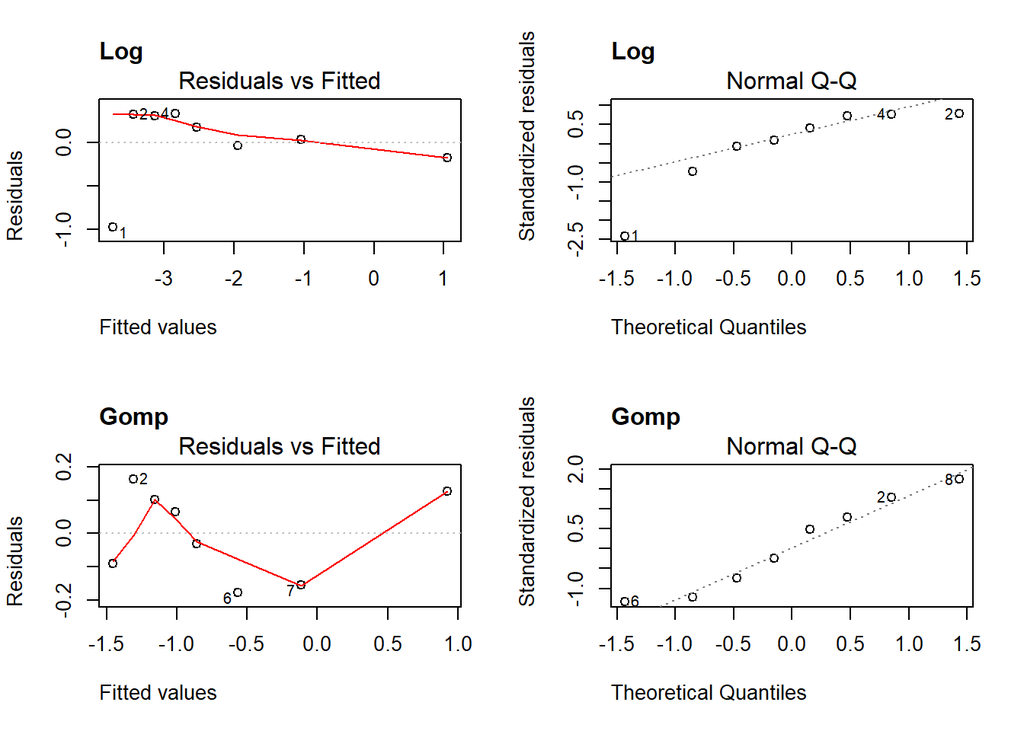

```r
# Gráficos dos resíduos do modelo
par(mfrow=c(2,2))
plot(aj_log_A, which=1:2, main="Log", adj=0, padj=0)

plot(aj_gom_A, which=1:2, main="Gomp", adj=0, padj=0)
```

## Amanda

```r
## MODELO LOGISTICO
# Valor de Yo
lm_coef_log_B <- round(coef(lm2),3)

# Yo estimado
y0_log_B <- 1/(1+exp(-lm_coef_log_B[1]))
y0_log_B
```

```
## (Intercept)
##    0.148679
```

```r
r_log_B <- lm_coef_log_B[2]
r_log_B
```

```
##     t
## 0.052
```

```r
# Valor predito pelo modelo Logístico
rg2$pred_logito <- lm_coef_log_B[1] + (lm_coef_log_B[2]*rg2$t)
rg2
```

```
##     t     y2        yexp       ymon       ylog       ygom pred_logito
## 1   0 0.0381 -3.26754100 0.03884478 -3.2286962 -1.1840377      -1.745
## 2   7 0.1362 -1.99363089 0.14641402 -1.8472169 -0.6899575      -1.381
## 3  14 0.2143 -1.54037838 0.24118024 -1.2991981 -0.4320281      -1.017
## 4  21 0.4092 -0.89355124 0.52627773 -0.3672735  0.1125516      -0.653
## 5  28 0.7031 -0.35225615 1.21435990  0.8621037  1.0433967      -0.289
## 6  42 0.8120 -0.20825494 1.67131332  1.4630584  1.5689923       0.439
## 7  63 0.9323 -0.07010063 2.69266910  2.6225685  2.6578235       1.531
## 8 112 0.9466 -0.05487866 2.92994453  2.8750659  2.9026307       4.079
```

```r
# Ajusta um modelo linear para predito versus y transformado para log
aj_log_B <- lm(ylog ~ pred_logito, data = rg2)

# Resíduo do ajuste (y* versus y^*)
res_aj_log_B <- resid(aj_log_B)
res_aj_log_B
```

```
##          1          2          3          4          5          6
## -1.4839019 -0.4692217 -0.2880022  0.2771233  1.1397014  1.0070576
##          7          8
##  1.0661702 -1.2489267
```

```r
# Coeficiente de determinação do modelo - R2
R2_log_B <- summary(aj_log_B)$r.squared
R2_log_B
```

```
## [1] 0.7736666
```

```r
# Coeficientes
summary(aj_log_B)$coef
```

```
##               Estimate Std. Error    t value    Pr(>|t|)
## (Intercept) 0.01362482  0.3985914 0.03418241 0.973840484
## pred_logito 1.00769005  0.2225096 4.52874876 0.003980436
```

```r
# Quadrado médio dos resíduos - QMR
qmr_log_B <- mean(aj_log_B$residuals^2)

# Raiz do quadrado médio dos resíduos (RMSE)
sqrt(mean(aj_log_B$residuals^2))
```

```
## [1] 0.9741341
```

```r
## MODELO GOMPERTZ
# Valor de Yo
lm_coef_gom_B <- round(coef(lm5), 3)

# Yo estimado
y0_gom_B <- exp(-exp(-c_lm5[1]))
y0_gom_B
```

```
## (Intercept)
##   0.1510429
```

```r
# Valor de r - Taxa
r_gom_B <- lm_coef_gom_B[2]
r_gom_B
```

```
##     t
## 0.039
```

```r
# Valor predito pelo modelo Gompito
rg5$pred_gompito <- lm_coef_gom_B[1] + (lm_coef_gom_B[2]*rg5$t)
rg5
```

```
##     t     y2        yexp       ymon       ylog       ygom pred_gompito
## 1   0 0.0381 -3.26754100 0.03884478 -3.2286962 -1.1840377       -0.637
## 2   7 0.1362 -1.99363089 0.14641402 -1.8472169 -0.6899575       -0.364
## 3  14 0.2143 -1.54037838 0.24118024 -1.2991981 -0.4320281       -0.091
## 4  21 0.4092 -0.89355124 0.52627773 -0.3672735  0.1125516        0.182
## 5  28 0.7031 -0.35225615 1.21435990  0.8621037  1.0433967        0.455
## 6  42 0.8120 -0.20825494 1.67131332  1.4630584  1.5689923        1.001
## 7  63 0.9323 -0.07010063 2.69266910  2.6225685  2.6578235        1.820
## 8 112 0.9466 -0.05487866 2.92994453  2.8750659  2.9026307        3.731
```

```r
# Ajusta um modelo linear para predito versus y transformado para log
aj_gom_B <- lm(ygom ~ pred_gompito, data = rg5)

# Resíduo do ajuste (y* versus y^*)
res_aj_gom_B <- resid(aj_gom_B)
res_aj_gom_B
```

```
##           1           2           3           4           5           6
## -0.54735957 -0.32334761 -0.33548636 -0.06097489  0.59980198  0.58526117
##           7           8
##  0.86388780 -0.78178251
```

```r
# Coeficiente de determinação do modelo - R2
R2_gom_B <- summary(aj_gom_B)$r.squared
R2_gom_B
```

```
## [1] 0.8450132
```

```r
# Mostra os coeficientes
summary(aj_gom_B)$coef
```

```
##                  Estimate Std. Error     t value    Pr(>|t|)
## (Intercept)  -0.006518987  0.2667029 -0.02444288 0.981291990
## pred_gompito  0.989260836  0.1729620  5.71952565 0.001238086
```

```r
# Quadrado médio dos resíduos - QMR
qmr_gom_B <- mean(aj_gom_B$residuals^2)

# Raiz do quadrado médio dos resíduos (RMSE)
sqrt(mean(aj_gom_B$residuals^2))
```

```
## [1] 0.5679133
```

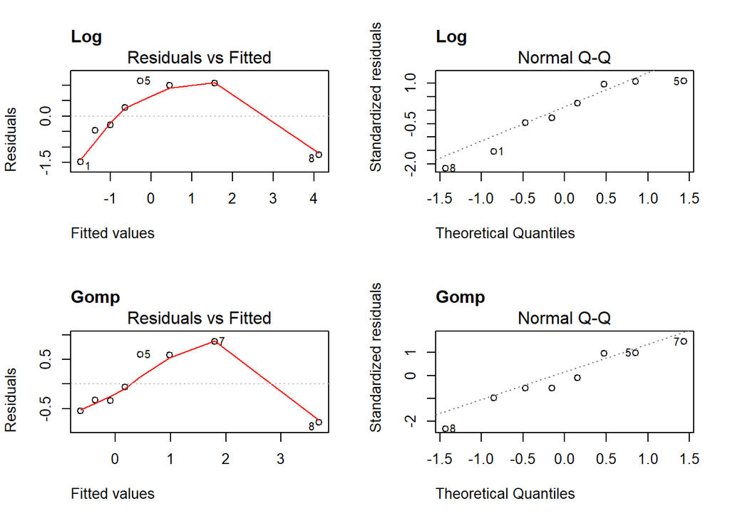

```r
#Gráficos dos Resíduos do Modelo
par(mfrow=c(2,2))
plot(aj_log_B, which=1:2, main="Log", adj=0, padj=0)

plot(aj_gom_B, which=1:2, main="Gomp", adj=0, padj=0)
```

## Margarita

```r
## MODELO LOGÍSTICO
# Valor de Yo
lm_coef_log_C <- round(coef(lm3),3)

# Yo estimado
y0_log_C <- 1/(1+exp(-lm_coef_log_C[1]))
y0_log_C
```

```
## (Intercept)
##  0.05651897
```

```r
r_log_C <- lm_coef_log_C[2]
r_log_C
```

```
##     t
## 0.045
```

```r
# Valor predito pelo modelo Logístico
rg3$pred_logito <- lm_coef_log_C[1] + (lm_coef_log_C[2]*rg3$t)
rg3
```

```
##     t     y3      yexp       ymon       ylog       ygom pred_logito
## 1   0 0.0478 -3.040730 0.04898018 -2.9917495 -1.1120975      -2.815
## 2   7 0.1125 -2.184802 0.11934676 -2.0654553 -0.7815252      -2.500
## 3  14 0.1243 -2.085057 0.13273171 -1.9523256 -0.7347963      -2.185
## 4  21 0.1478 -1.911895 0.15993404 -1.7519612 -0.6480950      -1.870
## 5  28 0.1935 -1.642478 0.21505138 -1.4274264 -0.4962059      -1.555
## 6  42 0.2296 -1.471417 0.26084542 -1.2105712 -0.3862256      -0.925
## 7  63 0.2808 -1.270113 0.32961580 -0.9404968 -0.2391056       0.020
## 8 112 0.9430 -0.058689 2.86470401  2.8060150  2.8355030       2.225
```

```r
# Ajusta um modelo linear para predito versus y transformado para log
aj_log_C <- lm(ylog ~ pred_logito, data = rg3)

# Resíduo do ajuste (y* versus y^*)
res_aj_log_C <- resid(aj_log_C)
res_aj_log_C
```

```
##          1          2          3          4          5          6
## -0.1766304  0.4329081  0.2292822  0.1128909  0.1206701 -0.2959860
##          7          8
## -0.9761786  0.5530436
```

```r
# Coeficiente de determinação do modelo - R2
R2_log_C <- summary(aj_log_C)$r.squared
R2_log_C
```

```
## [1] 0.9216608
```

```r
# Coeficientes
summary(aj_log_C)$coef
```

```
##               Estimate Std. Error    t value     Pr(>|t|)
## (Intercept) 0.01557033  0.2343442 0.06644215 0.9491844408
## pred_logito 1.00557351  0.1196857 8.40178837 0.0001548735
```

```r
# Quadrado médio dos resíduos - QMR
qmr_log_C <- mean(aj_log_C$residuals^2)

# Raiz do quadrado médio dos resíduos (RMSE)
sqrt(mean(aj_log_C$residuals^2))
```

```
## [1] 0.4534415
```

```r
## MODELO GOMPERTZ
# Valor de Yo
lm_coef_gom_C <- round(coef(lm6), 3)

# Yo estimado
y0_gom_C <- exp(-exp(-c_lm6[1]))
y0_gom_C
```

```
## (Intercept)
##   0.0227444
```

```r
# Valor de r - Taxa
r_gom_C <- lm_coef_gom_C[2]
r_gom_C
```

```
##     t
## 0.032
```

```r
# Valor predito pelo modelo Gompito
rg6$pred_gompito <- lm_coef_gom_C[1] + (lm_coef_gom_C[2]*rg6$t)
rg6
```

```
##     t     y3      yexp       ymon       ylog       ygom pred_gompito
## 1   0 0.0478 -3.040730 0.04898018 -2.9917495 -1.1120975       -1.331
## 2   7 0.1125 -2.184802 0.11934676 -2.0654553 -0.7815252       -1.107
## 3  14 0.1243 -2.085057 0.13273171 -1.9523256 -0.7347963       -0.883
## 4  21 0.1478 -1.911895 0.15993404 -1.7519612 -0.6480950       -0.659
## 5  28 0.1935 -1.642478 0.21505138 -1.4274264 -0.4962059       -0.435
## 6  42 0.2296 -1.471417 0.26084542 -1.2105712 -0.3862256        0.013
## 7  63 0.2808 -1.270113 0.32961580 -0.9404968 -0.2391056        0.685
## 8 112 0.9430 -0.058689 2.86470401  2.8060150  2.8355030        2.253
```

```r
# Ajusta um modelo linear para predito versus y transformado para log
aj_gom_C <- lm(ygom ~ pred_gompito, data = rg6)

# Resíduo do ajuste (y* versus y^*)
res_aj_gom_C <- resid(aj_gom_C)
res_aj_gom_C
```

```
##           1           2           3           4           5           6
##  0.21853513  0.32758270  0.15278690  0.01796348 -0.05167212 -0.38474121
##           7           8
## -0.90219527  0.62174039
```

```r
# Coeficiente de determinação do modelo - R2
R2_gom_C <- summary(aj_gom_C)$r.squared
R2_gom_C
```

```
## [1] 0.8608498
```

```r
# Coeficientes
summary(aj_gom_C)$coef
```

```
##                 Estimate Std. Error     t value     Pr(>|t|)
## (Intercept)  -0.01434075  0.1809870 -0.07923637 0.9394212307
## pred_gompito  0.98894957  0.1623217  6.09252693 0.0008899787
```

```r
# Quadrado médio dos resíduos - QMR
qmr_gom_C <- mean(aj_gom_C$residuals^2)

# Raiz do quadrado médio dos resíduos (RMSE)
sqrt(mean(aj_gom_C$residuals^2))
```

```
## [1] 0.4373139
```

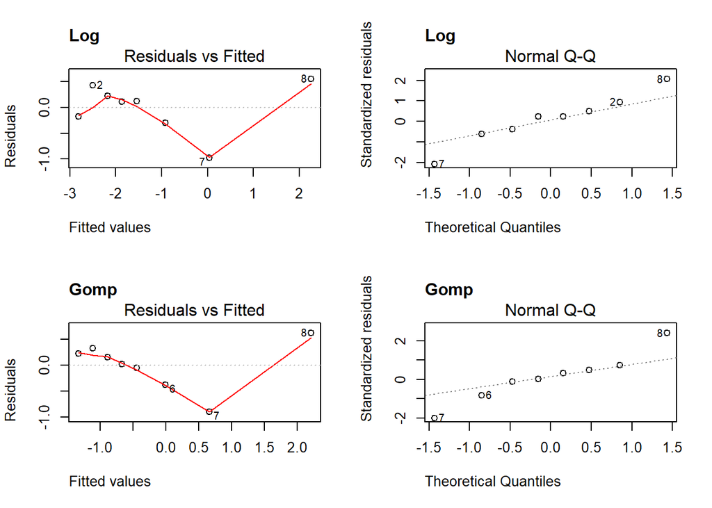

```r
par(mfrow=c(2,2))
plot(aj_log_C, which=1:2, main="Log", adj=0, padj=0)

plot(aj_gom_C, which=1:2, main="Gomp",adj=0, padj=0)
```

# Questão 6

Monte tabelas (uma para cada uma das três epidemias) mostrando os valores de y, y*, y^ (y predito) e y^* (para cada modelo) e resíduos (y* versus y^*), para cada tempo t.

## Magaly

```r
table_Magaly <- data.frame(rg1$t, rg1$y1, rg1$ylog, rg1$pred_logito, rg4$ygom, rg4$pred_gompito, res_aj_log_A, res_aj_gom_A)

names(table_Magaly)<-c("t", "y (severidade observada)", "y*(logito observado)", "y^*(logito predito)", "y*(gompito observado)", "y^*(gompito predito)", "Residual(baseado no logito)", "Residual(baseado em gompito)")

kable(table_Magaly)
```

| t | y (severidade observada) | y*(logito observado) | y^*(logito predito) | y*(gompito observado) | y^*(gompito predito) | Residual(baseado no logito) | Residual(baseado em gompito) |
| --- | --- | --- | --- | --- | --- | --- | --- |
| 0 | 0.0090 | -4.7014900 | -3.729 | -1.5498006 | -1.459 | -0.9726616 | -0.0907934 |
| 7 | 0.0429 | -3.1050361 | -3.428 | -1.1470479 | -1.312 | 0.3251530 | 0.1628871 |
| 14 | 0.0559 | -2.8266677 | -3.127 | -1.0592444 | -1.165 | 0.3048822 | 0.1016184 |
| 21 | 0.0759 | -2.4994036 | -2.826 | -0.9471452 | -1.018 | 0.3335070 | 0.0646454 |
| 28 | 0.0866 | -2.3558741 | -2.525 | -0.8946402 | -0.871 | 0.1783973 | -0.0319218 |
| 42 | 0.1223 | -1.9708278 | -1.923 | -0.7425458 | -0.577 | -0.0338348 | -0.1779718 |
| 63 | 0.2687 | -1.0012283 | -1.020 | -0.2731975 | -0.136 | 0.0398470 | -0.1558400 |
| 112 | 0.7056 | 0.8741091 | 1.087 | 1.0535239 | 0.893 | -0.1752901 | 0.1273761 |

## Amanda

```r
table_Amanda <- data.frame(rg2$t, rg2$y2, rg1$ylog, rg2$pred_logito, rg5$ygom, rg5$pred_gompito, res_aj_log_B, res_aj_gom_B)

names(table_Amanda)<-c("t", "y (severidade observada)", "y*(logito observado)", "y^*(logito predito)", "y*(gompito observado)", "y^*(gompito predito)", "Residual(baseado no logito)", "Residual(baseado em gompito)")

kable(table_Amanda)
```

[output not shown]

## Margarita

```r
table_Margarita <- data.frame(rg3$t, rg3$y3, rg3$ylog, rg3$pred_logito, rg6$ygom, rg6$pred_gompito, res_aj_log_C, res_aj_gom_C)

names(table_Margarita)<-c("t", "y (severidade observada)", "y*(logito observado)", "y^*(logito predito)", "y*(gompito observado)", "y^*(gompito predito)", "Residual(baseado no logito)", "Residual(baseado em gompito)")

kable(table_Margarita)
```

| t | y (severidade observada) | y*(logito observado) | y^*(logito predito) | y*(gompito observado) | y^*(gompito predito) | Residual(baseado no logito) | Residual(baseado em gompito) |
| --- | --- | --- | --- | --- | --- | --- | --- |
| 0 | 0.0478 | -2.9917495 | -2.815 | -1.1120975 | -1.331 | -0.1766304 | 0.2185351 |
| 7 | 0.1125 | -2.0654553 | -2.500 | -0.7815252 | -1.107 | 0.4329081 | 0.3275827 |
| 14 | 0.1243 | -1.9523256 | -2.185 | -0.7347963 | -0.883 | 0.2292822 | 0.1527869 |
| 21 | 0.1478 | -1.7519612 | -1.870 | -0.6480950 | -0.659 | 0.1128909 | 0.0179635 |
| 28 | 0.1935 | -1.4274264 | -1.555 | -0.4962059 | -0.435 | 0.1206701 | -0.0516721 |
| 42 | 0.2296 | -1.2105712 | -0.925 | -0.3862256 | 0.013 | -0.2959860 | -0.3847412 |
| 63 | 0.2808 | -0.9404968 | 0.020 | -0.2391056 | 0.685 | -0.9761786 | -0.9021953 |
| 112 | 0.9430 | 2.8060150 | 2.225 | 2.8355030 | 2.253 | 0.5530436 | 0.6217404 |

# Questão 7

Monte os gráficos de dispersão e a linha da regressão de y* versus t, para cada combinação modelo x epidemia. Ainda, mostre os gráficos dos resíduos para cada combinação. Dica: Monte os gráficos em duas colunas (uma para cada modelo), de modo a permitir uma melhor comparação visual. As epidemias (por tratamento) devem ser apresentadas na sequência.

### Magaly Logístico e Gompertz

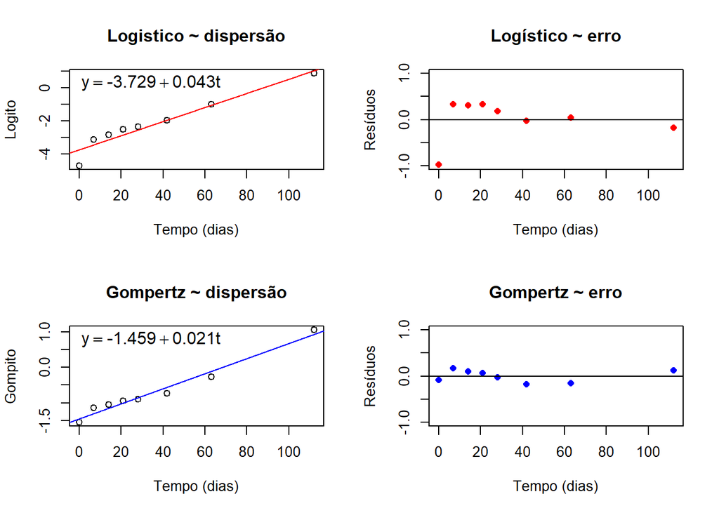

```r
table_A <- data.frame(rg1$t, rg1$y1, rg1$ylog, rg1$pred_logito, rg1$ygom, rg4$pred_gompito, res_aj_log_A, res_aj_gom_A)

## Gráficos de dispersão e a linha de regressão para cada modelo

## LOGÍSTICO
# Gráfico dispersão
par(mfrow=c(2,2))
plot (rg1.ylog ~ rg1.t, data = table_A, main="Logistico ~ dispersão", type = c("p"), ylab = "Logito", xlab = "Tempo (dias)")
abline ((coef(lm1)),col="RED")
lm_coef_A <- round(coef(lm1), 3)
mtext(bquote(y == .(lm_coef_A[1]) + .(lm_coef_A[2])*t), adj=0.1, padj=1.5)

# Gráfico residuos
plot(res_aj_log_A ~ rg1.t, data = table_A, ylab="Resíduos", xlab="Tempo (dias)",
     main="Logístico ~ erro", pch = 16, ylim=c(-1,1),col="RED")
abline (h=0)

##GOMPERTZ
# Gráfico dispersão
plot (rg1.ygom ~ rg1.t, data = table_A, main="Gompertz ~ dispersão", type = c("p"), ylab = "Gompito", xlab = "Tempo (dias)")
abline ((coef(lm4)),col="BLUE")
lm_coef_A <- round(coef(lm4), 3)
mtext(bquote(y == .(lm_coef_A[1]) + .(lm_coef_A[2])*t), adj=0.1, padj=1.5)
# Gráfico residuo
plot(res_aj_gom_A ~rg1.t, data = table_A, ylab="Resíduos", xlab="Tempo (dias)",
     main="Gompertz ~ erro", pch=16, ylim=c(-1,1), col="BLUE")
abline(h=0)
```

### Amanda

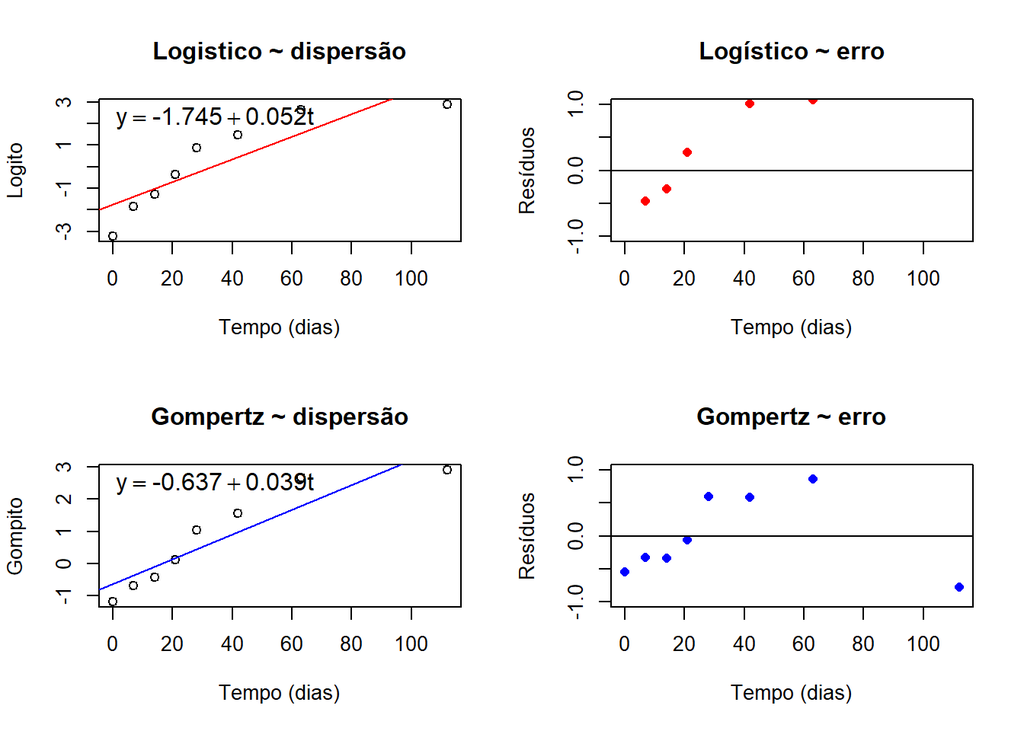

```r
table_B <- data.frame(rg2$t, rg2$y2, rg2$ylog, rg2$pred_logito, rg2$ygom, rg5$pred_gompito, res_aj_log_B, res_aj_gom_B)

## Gráficos de dispersão e a linha de regressão para cada modelo
# LOGÍSTICO
par(mfrow=c(2,2))

# Gráfico de dispersão
plot (rg2.ylog ~ rg2.t, data = table_B, main="Logistico ~ dispersão", type = c("p"), ylab = "Logito", xlab = "Tempo (dias)")
abline ((coef(lm2)),col="RED")
lm_coef_B <- round(coef(lm2), 3)
mtext(bquote(y == .(lm_coef_B[1]) + .(lm_coef_B[2])*t), adj=0.1, padj=1.5)

# Gráfico residuos
plot(res_aj_log_B ~ rg2.t, data = table_B, ylab="Resíduos", xlab="Tempo (dias)",
     main="Logístico ~ erro", pch = 16, ylim=c(-1,1),col="RED")
abline (h=0)

# GOMPERTZ
# Gráfico dispersão
plot (rg2.ygom ~ rg2.t, data = table_B, main="Gompertz ~ dispersão", type = c("p"), ylab = "Gompito", xlab = "Tempo (dias)")
abline ((coef(lm5)),col="BLUE")
lm_coef_B <- round(coef(lm5), 3)
mtext(bquote(y == .(lm_coef_B[1]) + .(lm_coef_B[2])*t), adj=0.1, padj=1.5)

# Gráfico residuo
plot(res_aj_gom_B ~rg2.t, data = table_B, ylab="Resíduos", xlab="Tempo (dias)",
     main="Gompertz ~ erro", pch=16, ylim=c(-1,1), col="BLUE")
abline(h=0)
```

### Margarita

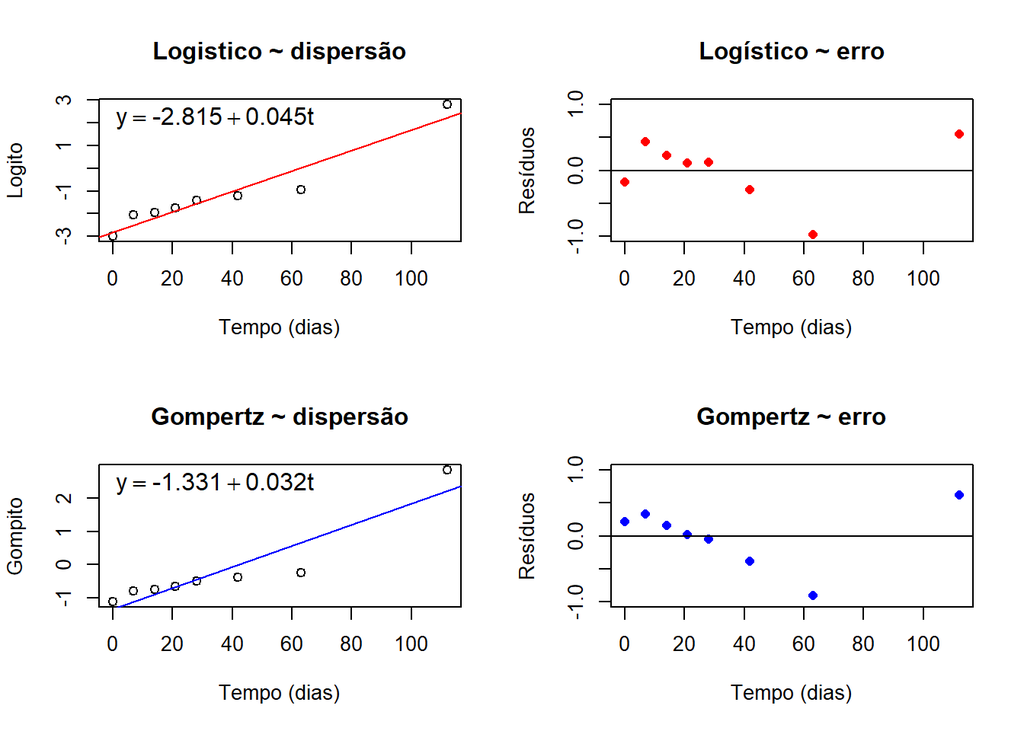

```r
table_C <- data.frame(rg3$t, rg3$y3, rg3$ylog, rg3$pred_logito, rg3$ygom, rg6$pred_gompito, res_aj_log_C, res_aj_gom_C)

## Gráficos de dispersão e a linha de regressão para cada modelo
# LOGÍSTICO
par(mfrow=c(2,2))

# Gráfico de dispersão
plot (rg3.ylog ~ rg3.t, data = table_C, main="Logistico ~ dispersão", type = c("p"), ylab = "Logito", xlab = "Tempo (dias)")
abline ((coef(lm3)),col="RED")
lm_coef_C <- round(coef(lm3), 3)
mtext(bquote(y == .(lm_coef_C[1]) + .(lm_coef_C[2])*t), adj=0.1, padj=1.5)

# Gráfico residuos
plot(res_aj_log_C ~ rg3.t, data = table_C, ylab="Resíduos", xlab="Tempo (dias)",
     main="Logístico ~ erro", pch = 16, ylim=c(-1,1),col="RED")
abline (h=0)

# Gompertz
# Gráfico dispersão
plot (rg3.ygom ~ rg3.t, data = table_C, main="Gompertz ~ dispersão", type = c("p"), ylab = "Gompito", xlab = "Tempo (dias)")
abline ((coef(lm6)),col="BLUE")
lm_coef_C <- round(coef(lm6), 3)
mtext(bquote(y == .(lm_coef_C[1]) + .(lm_coef_C[2])*t), adj=0.1, padj=1.5)

# Gráfico residuo
plot(res_aj_gom_C ~rg3.t, data = table_C, ylab="Resíduos", xlab="Tempo (dias)",
     main="Gompertz ~ erro", pch=16, ylim=c(-1,1), col="BLUE")
abline(h=0)
```

# Questão 8

Com base nos parâmetros estimados pelos modelos (y0* e r*), calcule o valor de y^ (predito pelo modelo após a transformação reversa) para cada modelo. Faça o cálculo para cada data de avaliação (tempo t) e monte uma tabela mostrando o y observado e y predito pelo modelo. Por fim, calcule o coeficiente de determinação da relação desses dois valores (R*2) para escolher o melhor modelo. Apresente um gráfico para cada modelo mostrando os dados observados e a linha dos dados preditos pelo modelo.

### Magaly

```r
# Gráfico do progresso da doença
#Curva do modelo Logístico
par(mfrow=c(1,2))
plot (y1 ~ t, data = rg1, main="Logistico",  type=c("p"),
      ylab="Severidade (%)", xlab="Tempo (dias)", ylim=c(0,1),col="RED")

lm_coefl_A <- round(coef(lm1), 3)
lm_coefl_A
```

```
## (Intercept)           t
##      -3.729       0.043
```

```r
y0 = 1/ (1+exp(-lm_coefl_A[1]))
y0
```

```
## (Intercept)
##  0.02345356
```

```r
max=120
r = lm_coefl_A[2]

# Taxa do modelo logístico
curve( 1/(1+((1-y0)/y0)*exp(-r*x)), from=-5, to=max, add=T, ylab="y", xlab="t", ylim=c(0,1), lty=1, lwd=2,col="BLUE")

# Curva do modelo de gompertz
plot ( y1 ~ t, data = rg1, main="Gompertz", type=c("p"),
       ylab="Severidade (%)", xlab="Tempo (dias)", ylim = c(0,1),col="BLUE")

lm_coefg_A <- round(coef(lm4), 3)
lm_coefg_A
```

```
## (Intercept)           t
##      -1.459       0.021
```

```r
y0 = exp(-exp(-lm_coefg_A[1]))
y0
```

```
## (Intercept)
##  0.01354611
```

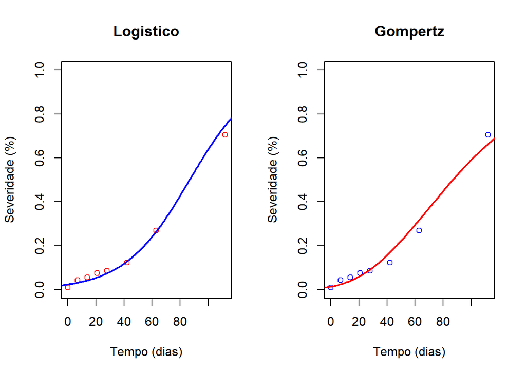

```r
max=120
r = lm_coefg_A[2]

# Taxa do modelo gompertz
curve(exp(log(y0)*exp(-r*x)), from=-5, to=max, add=T, ylab="y", xlab="t", ylim=c(0,1), lty=1, lwd=2,col="RED")
```

### Amanda

```r
# Gráfico do progresso da doença
# Curva do modelo Logistico
par(mfrow=c(1,2))

plot (y2 ~ t, data = rg2, main="Logistico",  type=c("p"),
      ylab="Severidade (%)", xlab="Tempo (dias)", ylim=c(0,1),col="RED")

lm_coefl_B <- round(coef(lm2), 3)
lm_coefl_B
```

```
## (Intercept)           t
##      -1.745       0.052
```

```r
y0 = 1/ (1+exp(-lm_coefl_B[1]))
y0
```

```
## (Intercept)
##    0.148679
```

```r
max=120
r = lm_coefl_B[2]

# Estimado da taxa do logístico
curve( 1/(1+((1-y0)/y0)*exp(-r*x)), from=-5, to=max, add=T, ylab="y", xlab="t", ylim=c(0,1), lty=1, lwd=2,col="BLUE")

# curva do modelo de gompertz
plot ( y2 ~ t, data = rg1, main="Gompertz", type=c("p"),
       ylab="Severidade (%)", xlab="Tempo (dias)", ylim = c(0,1),col="BLUE")

lm_coefg_B <- round(coef(lm5), 3)
lm_coefg_B
```

```
## (Intercept)           t
##      -0.637       0.039
```

```r
y0 = exp(-exp(-lm_coefg_B[1]))
y0
```

```
## (Intercept)
##    0.150951
```

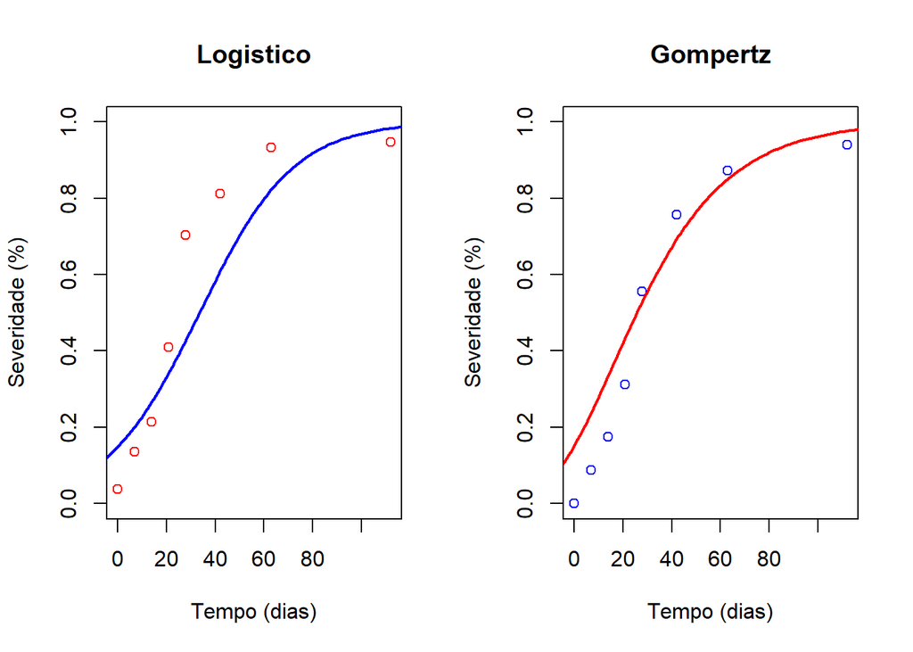

```r
max=120
r = lm_coefg_B[2]

# Estimado da taxa do modelo gompertz
curve(exp(log(y0)*exp(-r*x)), from=-5, to=max, add=T, ylab="y", xlab="t", ylim=c(0,1), lty=1, lwd=2,col="RED")
```

## Margarita

```r
# Gráfico do progresso da doença
#Curva de Modelo Logístico
par(mfrow=c(1,2))

plot (y3 ~ t, data = rg3, main="Logistico",  type=c("p"),
      ylab="Severidade (%)", xlab="Tempo (dias)", ylim=c(0,1),col="RED")

lm_coefl_C <- round(coef(lm3), 3)
lm_coefl_C
```

```
## (Intercept)           t
##      -2.815       0.045
```

```r
y0 = 1/ (1+exp(-lm_coefl_C[1]))
y0
```

```
## (Intercept)
##  0.05651897
```

```r
max=120
r = lm_coefl_C[2]

# Estimado da taxa  do logístico
curve( 1/(1+((1-y0)/y0)*exp(-r*x)), from=-5, to=max, add=T, ylab="y", xlab="t", ylim=c(0,1), lty=1, lwd=2,col="BLUE")

# curva do modelo de gompertz
plot ( y3 ~ t, data = rg1, main="Gompertz", type=c("p"),
       ylab="Severidade (%)", xlab="Tempo (dias)", ylim = c(0,1),col="BLUE")

lm_coefg_C <- round(coef(lm6), 3)
lm_coefg_C
```

```
## (Intercept)           t
##      -1.331       0.032
```

```r
y0 = exp(-exp(-lm_coefg_A[1]))
y0
```

```
## (Intercept)
##  0.01354611
```

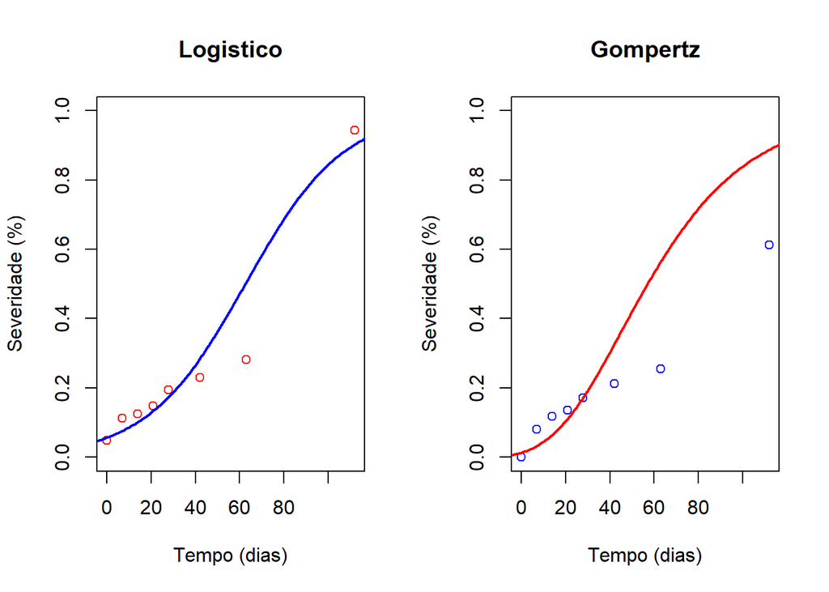

```r
max=120
r = lm_coefg_C[2]

# Estimado da taxa do modelo gompertz
curve(exp(log(y0)*exp(-r*x)), from=-5, to=max, add=T, ylab="y", xlab="t", ylim=c(0,1), lty=1, lwd=2,col="RED")
```

## Cálculo do Coeficiente de determinação

```r
#MAGALY
## Logistico x Gompertz
R2_l_A=summary(aj_log_A)$r.squared
R2_l_A#Coeficiente de determinação Logistico
```

```
## [1] 0.9286688
```

```r
R2_g_A=summary(aj_gom_A)$r.squared
R2_g_A#Coeficiente de determinação Gompertz
```

```
## [1] 0.9722172
```

```r
#AMANDA
## Logistico x Gompertz
R2_l_B=summary(aj_log_B)$r.squared
R2_l_B#Coeficiente de determinação Logistico
```

```
## [1] 0.7736666
```

```r
R2_g_B=summary(aj_gom_B)$r.squared
R2_g_B#Coeficiente de determinação Gompertz
```

```
## [1] 0.8450132
```

```r
# MARGARRITA
## Logistico x Gompertz
R2_l_C=summary(aj_log_C)$r.squared
R2_l_C#Coeficiente de determinação Logistico
```

```
## [1] 0.9216608
```

```r
R2_g_C=summary(aj_gom_C)$r.squared
R2_g_C#Coeficiente de determinação Gompertz
```

```
## [1] 0.8608498
```